# Rape project 2018 - weekly analysis

Internal only

MaryJo Webster

Last updated: 2019-06-12

Other pages: [Highlights for sources](http://strib-data-public.s3-us-west-1.amazonaws.com/projects/rape/highlights.html)

[Analysis of cases where victim was intoxicated](http://strib-data-internal.s3-us-west-1.amazonaws.com/projects/rape/liquor.html)

http://strib-data-public.s3-us-west-1.amazonaws.com/projects/rape/top4.html

# Number of cases reviewed

| dept | count |
| --- | --- |
| All other | 671 |
| Minneapolis | 554 |
| St. Paul | 240 |
| Total | 1465 |

## By department

|  | department | count |
| --- | --- | --- |
| 1 | Minneapolis | 554 |
| 2 | St. Paul | 240 |
| 3 | Anoka | 124 |
| 4 | Duluth | 112 |
| 5 | Brooklyn Park | 74 |
| 6 | Rochester | 58 |
| 7 | Mankato | 54 |
| 8 | St. Cloud | 49 |
| 9 | Wright County | 39 |
| 10 | Itasca | 28 |

[output cut: 9 more lines]

## Pct of cases with an arrest

Percentage of cases with a named suspect that result in arrest

|  | suspectarrested |  |  |  |  |
| --- | --- | --- | --- | --- | --- |
| suspectflag | Yes | No | Cannot determine | N/A | Total |
| Named suspect | 29% (309) | 67% (718) | 5% (50) | 0% (1) | 100% (1078) |
| None | 0% (1) | 98% (319) | 2% (6) | 0% (0) | 100% (326) |
| Partial name | 3% (2) | 95% (58) | 2% (1) | 0% (0) | 100% (61) |

## Victim involvement-Sent for prosecution

Cases with a victim who cooperates throughout the case are far more likely to be sent for prosecution

|  | sentforprosecution |  |  |  |
| --- | --- | --- | --- | --- |
| victiminvolve | Yes | No | Cannot determine | N/A |
| Withdrew at some point | 2% | 97% | 1% | 0% |
| Cooperated throughout | 46% | 51% | 3% | 0% |
| Unknown | 15% | 73% | 12% | 0% |
| N/A | 67% | 33% | 0% | 0% |

## Cases assigned to an investigator

|  | investigatorsassigned |  |  |
| --- | --- | --- | --- |
| department | Yes | No | NA_ |
| Anoka | 100% (124) | 0% (0) | 0% (0) |
| Bloomington | 88% (15) | 12% (2) | 0% (0) |
| Brainerd | 86% (6) | 14% (1) | 0% (0) |
| Brooklyn Center | 100% (20) | 0% (0) | 0% (0) |
| Brooklyn Park | 95% (70) | 4% (3) | 1% (1) |
| Cass County | 86% (18) | 10% (2) | 5% (1) |
| Duluth | 31% (35) | 67% (75) | 2% (2) |
| Grand Rapids | 36% (4) | 64% (7) | 0% (0) |
| Itasca | 61% (17) | 39% (11) | 0% (0) |
| Mankato | 19% (10) | 81% (44) | 0% (0) |
| Minneapolis | 82% (452) | 18% (100) | 0% (2) |
| Moorhead | 94% (16) | 6% (1) | 0% (0) |
| Rochester | 91% (53) | 5% (3) | 3% (2) |
| Shakopee | 86% (6) | 14% (1) | 0% (0) |
| St. Cloud | 78% (38) | 18% (9) | 4% (2) |
| St. Louis County | 80% (20) | 20% (5) | 0% (0) |
| St. Paul | 99% (238) | 1% (2) | 0% (0) |
| U-Minnesota | 88% (7) | 13% (1) | 0% (0) |
| Wright County | 92% (36) | 8% (3) | 0% (0) |
| Total | 81% (1185) | 18% (270) | 1% (10) |

## Cases by legal type

|  | legaltype |  |  |  |  |
| --- | --- | --- | --- | --- | --- |
| casetype | Force/Threat/Fear | Incapacitation | Both | Unknown | N/A |
| Acquaintance | 62% | 15% | 15% | 8% | 0% |
| Stranger | 68% | 12% | 15% | 5% | 0% |
| Unclear | 25% | 17% | 23% | 35% | 0% |
| NA | 0% | 0% | 0% | 0% | 100% |
| Total | 60% | 15% | 15% | 9% | 0% |

# Acquaintance vs STranger

| casetype | count | pct |
| --- | --- | --- |
| Acquaintance | 83 | 0.6974790 |
| Stranger | 33 | 0.2773109 |
| Unclear | 3 | 0.0252101 |

## Conviction by case type

|  | conviction |  |  |  |  |
| --- | --- | --- | --- | --- | --- |
| casetype | Yes | No | Case still pending | Cannot determine | NA_ |
| Acquaintance | 8% (83) | 86% (944) | 0% (4) | 5% (52) | 1% (9) |
| Stranger | 12% (33) | 85% (228) | 0% (0) | 2% (5) | 0% (1) |
| Unclear | 3% (3) | 93% (98) | 0% (0) | 3% (3) | 1% (1) |
| NA | 0% (0) | 100% (1) | 0% (0) | 0% (0) | 0% (0) |
| Total | 8% (119) | 87% (1271) | 0% (4) | 4% (60) | 1% (11) |

## Pct of cases involving suspect of color

| suspect_personofcolor | count | pct_d |
| --- | --- | --- |
| NA | 30 | 2.6% |
| No | 276 | 24.2% |
| Unknown | 279 | 24.5% |
| Yes | 554 | 48.6% |

## Declined cases

sent for prosecution = yes

| department_collapse/declinedcase | Declined | NA |
| --- | --- | --- |
| All other | 57% (152) | 43% (117) |
| Minneapolis | 29% (32) | 71% (80) |
| St. Paul | 59% (30) | 41% (21) |
| Total | 50% (214) | 50% (218) |

## Reporting delays

| delay/conviction | Yes | No | Case still pending | Cannot determine | NA_ |
| --- | --- | --- | --- | --- | --- |
| delay | 5% | 89% | 0% | 4% | 1% |
| no delay | 10% | 85% | 0% | 4% | 1% |
| unknown | 5% | 91% | 0% | 4% | 0% |
| Total | 8% | 87% | 0% | 4% | 1% |

## Arrest rates

Only cases with a named suspect

| casetype/suspectarrested | Yes | No | Cannot determine | N/A |
| --- | --- | --- | --- | --- |
| Acquaintance | 26% (246) | 69% (656) | 5% (46) | 0% (1) |
| Stranger | 59% (54) | 38% (35) | 3% (3) | 0% (0) |
| Unclear | 25% (9) | 72% (26) | 3% (1) | 0% (0) |
| NA | 0% (0) | 100% (1) | 0% (0) | 0% (0) |
| Total | 29% (309) | 67% (718) | 5% (50) | 0% (1) |

## Charges filed

Percentage of all cases where charges were filed

|  | chargesfiled |  |  |  |  |
| --- | --- | --- | --- | --- | --- |
| department_collapse | Yes | No | Cannot determine | NEED TO CHECK | N/A |
| All other | 14% (95) | 79% (528) | 7% (45) | 0% (2) | 0% (1) |
| Minneapolis | 14% (78) | 85% (472) | 1% (3) | 0% (1) | 0% (0) |
| St. Paul | 9% (21) | 91% (219) | 0% (0) | 0% (0) | 0% (0) |
| Total | 13% (194) | 83% (1219) | 3% (48) | 0% (3) | 0% (1) |

Charges filed by case type

|  | chargesfiled |  |  |  |  |
| --- | --- | --- | --- | --- | --- |
| casetype | Yes | No | Cannot determine | NEED TO CHECK | N/A |
| Acquaintance | 14% (149) | 82% (897) | 4% (42) | 0% (3) | 0% (1) |
| Stranger | 15% (41) | 84% (223) | 1% (3) | 0% (0) | 0% (0) |
| Unclear | 4% (4) | 93% (98) | 3% (3) | 0% (0) | 0% (0) |
| NA | 0% (0) | 100% (1) | 0% (0) | 0% (0) | 0% (0) |
| Total | 13% (194) | 83% (1219) | 3% (48) | 0% (3) | 0% (1) |

## Victim involvement rates

Percentage of cases where victim drop outs, by department

|  | victiminvolve |  |  |  |
| --- | --- | --- | --- | --- |
| department_collapse | Withdrew at some point | Cooperated throughout | Unknown | N/A |
| All other | 25% | 66% | 8% | 0% |
| Minneapolis | 41% | 56% | 3% | 0% |
| St. Paul | 43% | 52% | 5% | 0% |
| Total | 34% | 60% | 6% | 0% |

## Conviction rates

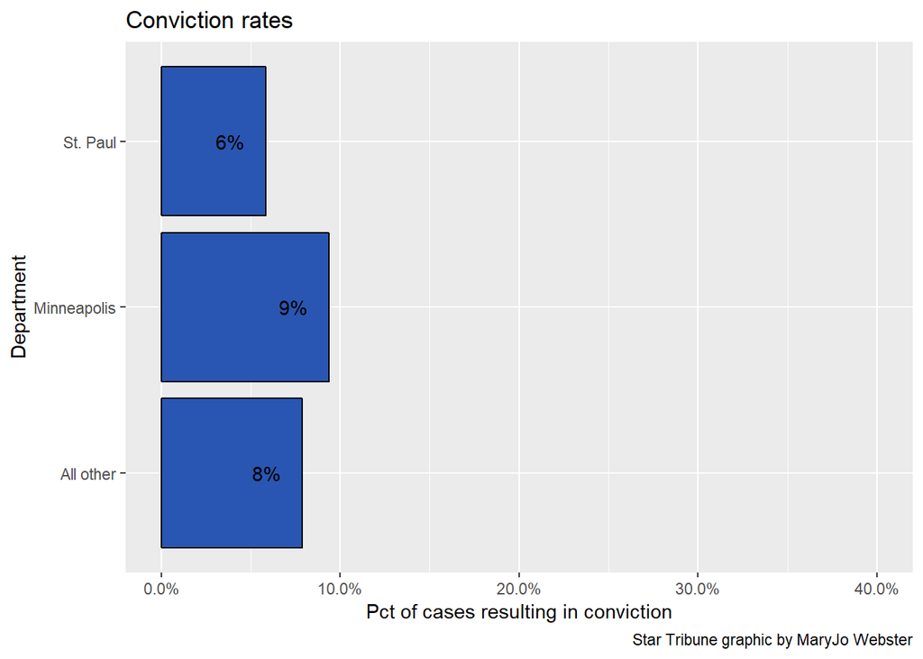

Conviction by case type:

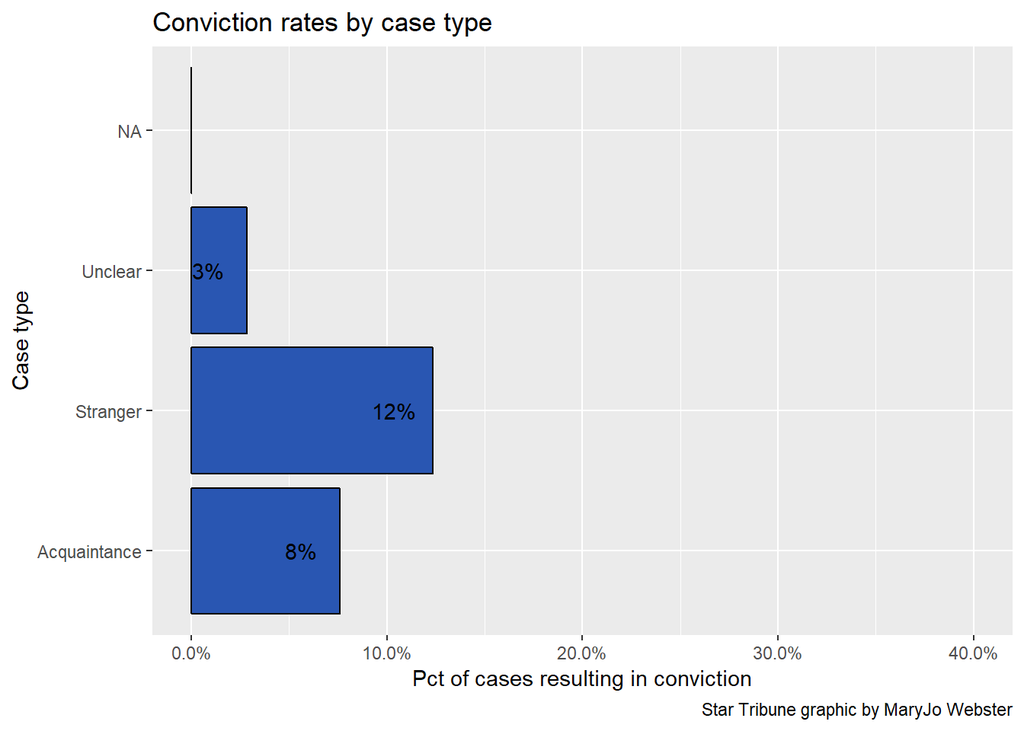

Conviction By Department  
Percentage of cases resulting in conviction

| department | convictions | totalcases | convict_rate |
| --- | --- | --- | --- |
| Moorhead | 3 | 17 | 17.6% |
| Rochester | 9 | 58 | 15.5% |
| Cass County | 3 | 21 | 14.3% |
| Anoka County | 16 | 124 | 12.9% |
| St. Louis County | 3 | 25 | 12.0% |
| St. Cloud | 5 | 49 | 10.2% |
| Minneapolis | 52 | 554 | 9.4% |
| Grand Rapids | 1 | 11 | 9.1% |
| Brooklyn Park | 5 | 74 | 6.8% |
| Bloomington | 1 | 17 | 5.9% |
| St. Paul | 14 | 240 | 5.8% |
| Mankato | 3 | 54 | 5.6% |
| Brooklyn Center | 1 | 20 | 5.0% |
| Duluth | 3 | 112 | 2.7% |
| Brainerd | 0 | 7 | 0.0% |
| Itasca County | 0 | 28 | 0.0% |
| Shakopee | 0 | 7 | 0.0% |
| Wright County | 0 | 39 | 0.0% |

# Sent for prosecution by department

|  | sentforprosecution |  |  |  |
| --- | --- | --- | --- | --- |
| department_collapse | Yes | No | Cannot determine | N/A |
| All other | 40% (269) | 55% (368) | 5% (34) | 0% (0) |
| Minneapolis | 20% (112) | 79% (438) | 1% (4) | 0% (0) |
| St. Paul | 21% (51) | 79% (189) | 0% (0) | 0% (0) |
| Total | 29% (432) | 68% (995) | 3% (38) | 0% (0) |

## Victim involvement - prosecution

|  | sentforprosecution |  |  |  |
| --- | --- | --- | --- | --- |
| victiminvolve | Yes | No | Cannot determine | N/A |
| Withdrew at some point | 2% (11) | 97% (484) | 1% (4) | 0% (0) |
| Cooperated throughout | 46% (406) | 51% (447) | 3% (24) | 0% (0) |
| Unknown | 15% (13) | 73% (63) | 12% (10) | 0% (0) |
| N/A | 67% (2) | 33% (1) | 0% (0) | 0% (0) |
| Total | 29% (432) | 68% (995) | 3% (38) | 0% (0) |

## Victim interview

Percentage of cases where victim is interviewed by investigator

| victiminterviewed | count | pct_d |
| --- | --- | --- |
| Yes | 620 | 42.3% |
| No | 438 | 29.9% |
| Attempted | 344 | 23.5% |
| Other | 62 | 4.2% |
| N/A | 1 | 0.1% |

# Cases investigated, not sent for prosecution

Victim involvement by police actions

## Victim interview

Did investigators conduct a forensic interview with victim?

|  | victiminterviewed |  |  |  |  |
| --- | --- | --- | --- | --- | --- |
| victiminvolve | Yes | Attempted | No | Other | N/A |
| Withdrew at some point | 11% | 71% | 15% | 2% | 0% |
| Cooperated throughout | 59% | 3% | 33% | 5% | 0% |
| Unknown | 14% | 14% | 59% | 14% | 0% |
| N/A | 0% | 0% | 100% | 0% | 0% |
| Total | 31% | 40% | 25% | 4% | 0% |

## Suspect interviewed

Only cases with a named suspect  
Did investigators interview the suspect?

suspectinterviewed

victiminvolve

Yes

Attempted

No

Other

Suspect unknown

N/A

Withdrew at some point

19%

4%

72%

1%

4%

0%

Cooperated throughout

48%

6%

42%

1%

2%

0%

Unknown

14%

7%

68%

7%

4%

0%

N/A

Total

31%

5%

59%

2%

3%

0%

## Evidence collection

Only cases with no delay in reporting  
Was all potential evidence collected?

|  | evidence2 |  |  |
| --- | --- | --- | --- |
| victiminvolve | All collected | Not all collected | Unknown |
| Withdrew at some point | 57% | 27% | 16% |
| Cooperated throughout | 62% | 28% | 10% |
| Unknown | 55% | 19% | 26% |
| N/A | 100% | 0% | 0% |
| Total | 59% | 27% | 14% |

## Interview witnesses

How often potential witnesses were not interviewed

|  | potentialwitnesses_notinterviewed |  |  |  |
| --- | --- | --- | --- | --- |
| victiminvolve | Yes | No | Not applicable | N/A |
| Withdrew at some point | 42% | 40% | 18% | 0% |
| Cooperated throughout | 41% | 48% | 11% | 0% |
| Unknown | 43% | 32% | 20% | 5% |
| N/A | 0% | 100% | 0% | 0% |
| Total | 42% | 43% | 15% | 1% |

# BUCKETS

Comparing police actions on cases sent for prosecution versus those not sent

## Victim interview

|  | victiminterviewed |  |  |  |  |
| --- | --- | --- | --- | --- | --- |
| group2 | Yes | Attempted | No | Other | N/A |
| Not sent for prosecution | 25% | 33% | 37% | 5% | 0% |
| Sent for prosecution | 84% | 1% | 12% | 3% | 0% |
| NA | 13% | 25% | 63% | 0% | 0% |
| Total | 42% | 23% | 30% | 4% | 0% |

## Suspect interview

Only cases with named suspect

|  | suspectinterviewed |  |  |  |  |  |
| --- | --- | --- | --- | --- | --- | --- |
| group2 | Yes | Attempted | No | Other | Suspect unknown | N/A |
| Not sent for prosecution | 30% | 4% | 63% | 3% | 1% | 0% |
| Sent for prosecution | 70% | 15% | 13% | 2% | 0% | 0% |
| NA | 0% | 0% | 100% | 0% | 0% | 0% |
| Total | 46% | 8% | 43% | 2% | 1% | 0% |

## Evidence not collected

Only cases without a delay in reporting

|  | evidence2 |  |  |
| --- | --- | --- | --- |
| group2 | All collected | Not all collected | Unknown |
| Not sent for prosecution | 56% | 30% | 14% |
| Sent for prosecution | 78% | 11% | 11% |
| NA | 60% | 0% | 40% |
| Total | 63% | 24% | 13% |

## Witnesses not interviewed

|  | witness2 |  |  |
| --- | --- | --- | --- |
| group2 | All witnesses interviewed | Not all witnesses interviewed | Unknown |
| Not sent for prosecution | 42% | 43% | 16% |
| Sent for prosecution | 62% | 31% | 7% |
| NA | 38% | 50% | 13% |
| Total | 48% | 39% | 13% |

## Victim involvement

|  | victiminvolve |  |  |  |
| --- | --- | --- | --- | --- |
| group2 | Withdrew at some point | Cooperated throughout | Unknown | N/A |
| Not sent for prosecution | 47% | 46% | 7% | 0% |
| Sent for prosecution | 3% | 94% | 3% | 0% |
| NA | 38% | 50% | 13% | 0% |
| Total | 34% | 60% | 6% | 0% |

## Named suspects

How often cases had named suspects (not including partial names or nicknames)

|  | suspectflag |  |  |
| --- | --- | --- | --- |
| group2 | Named suspect | None | Partial name |
| Not sent for prosecution | 63% | 31% | 6% |
| Sent for prosecution | 99% | 1% | 0% |
| NA | 50% | 38% | 13% |
| Total | 74% | 22% | 4% |

## Assigned to investigators

How often cases were assigned to investigators

|  | investigatorsassigned |  |  |
| --- | --- | --- | --- |
| department | Yes | No | NA_ |
| Anoka | 100% (124) | 0% (0) | 0% (0) |
| Bloomington | 88% (15) | 12% (2) | 0% (0) |
| Brainerd | 86% (6) | 14% (1) | 0% (0) |
| Brooklyn Center | 100% (20) | 0% (0) | 0% (0) |
| Brooklyn Park | 95% (70) | 4% (3) | 1% (1) |
| Cass County | 86% (18) | 10% (2) | 5% (1) |
| Duluth | 31% (35) | 67% (75) | 2% (2) |
| Grand Rapids | 36% (4) | 64% (7) | 0% (0) |
| Itasca | 61% (17) | 39% (11) | 0% (0) |
| Mankato | 19% (10) | 81% (44) | 0% (0) |
| Minneapolis | 82% (452) | 18% (100) | 0% (2) |
| Moorhead | 94% (16) | 6% (1) | 0% (0) |
| Rochester | 91% (53) | 5% (3) | 3% (2) |
| Shakopee | 86% (6) | 14% (1) | 0% (0) |
| St. Cloud | 78% (38) | 18% (9) | 4% (2) |
| St. Louis County | 80% (20) | 20% (5) | 0% (0) |
| St. Paul | 99% (238) | 1% (2) | 0% (0) |
| U-Minnesota | 88% (7) | 13% (1) | 0% (0) |
| Wright County | 92% (36) | 8% (3) | 0% (0) |
| Total | 81% (1185) | 18% (270) | 1% (10) |

# Cases that involve a repeat offender

|  | investigatorsassigned |  |
| --- | --- | --- |
| department_collapse | Yes | No |
| All other | 79% (27) | 21% (7) |
| Minneapolis | 83% (25) | 17% (5) |
| St. Paul | 100% (21) | 0% (0) |
| Total | 86% (73) | 14% (12) |

Repeat offender cases - victim interview

|  | victiminterviewed |  |  |  |  |
| --- | --- | --- | --- | --- | --- |
| department_collapse | Yes | Attempted | No | Other | N/A |
| All other | 59% (20) | 9% (3) | 26% (9) | 6% (2) | 0% (0) |
| Minneapolis | 60% (18) | 20% (6) | 20% (6) | 0% (0) | 0% (0) |
| St. Paul | 33% (7) | 24% (5) | 33% (7) | 10% (2) | 0% (0) |
| Total | 53% (45) | 16% (14) | 26% (22) | 5% (4) | 0% (0) |

Repeat offender cases - evidence collection

|  | evidence2 |  |  |
| --- | --- | --- | --- |
| department_collapse | All collected | Not all collected | Unknown |
| All other | 65% (22) | 26% (9) | 9% (3) |
| Minneapolis | 63% (19) | 13% (4) | 23% (7) |
| St. Paul | 81% (17) | 19% (4) | 0% (0) |
| Total | 68% (58) | 20% (17) | 12% (10) |

Repeat offender cases - witness interviews

|  | witness2 |  |  |
| --- | --- | --- | --- |
| department_collapse | All witnesses interviewed | Not all witnesses interviewed | Unknown |
| All other | 44% (15) | 53% (18) | 3% (1) |
| Minneapolis | 60% (18) | 33% (10) | 7% (2) |
| St. Paul | 52% (11) | 38% (8) | 10% (2) |
| Total | 52% (44) | 42% (36) | 6% (5) |

Repeat offender cases - sent for prosecution

|  | sentforprosecution |  |  |  |
| --- | --- | --- | --- | --- |
| department_collapse | Yes | No | Cannot determine | N/A |
| All other | 56% (19) | 41% (14) | 3% (1) | 0% (0) |
| Minneapolis | 50% (15) | 50% (15) | 0% (0) | 0% (0) |
| St. Paul | 67% (14) | 33% (7) | 0% (0) | 0% (0) |
| Total | 56% (48) | 42% (36) | 1% (1) | 0% (0) |

Percent of cases involving a repeat offender  
sent for prosecution that resulted in conviction

conviction

sentforprosecution

Yes

No

Case still pending

Cannot determine

Yes

54%

46%

0%

0%

No

0%

100%

0%

0%

Cannot determine

0%

100%

0%

0%

N/A

Total

31%

69%

0%

0%

Percent of cases sent for prosecution that resulted in conviction  
Cases that do NOT involve a repeat offender

conviction

sentforprosecution

Yes

No

Case still pending

Cannot determine

NA_

Yes

25%

63%

1%

10%

2%

No

0%

100%

0%

0%

0%

Cannot determine

0%

33%

0%

57%

10%

N/A

Total

9%

84%

0%

5%

1%

# Was there a pretext call?

Only cases involving named suspect and cooperative victim

| pretextcall | count | pct |
| --- | --- | --- |
| NA | 1 | 0.0013908 |
| No | 299 | 0.4158554 |
| Not applicable | 383 | 0.5326843 |
| Yes | 36 | 0.0500695 |

# Investigator assigned by department

|  | investigatorsassigned |  |  |
| --- | --- | --- | --- |
| department | Yes | No | NA_ |
| Anoka | 100% (124) | 0% (0) | 0% (0) |
| Bloomington | 88% (15) | 12% (2) | 0% (0) |
| Brainerd | 86% (6) | 14% (1) | 0% (0) |
| Brooklyn Center | 100% (20) | 0% (0) | 0% (0) |
| Brooklyn Park | 95% (70) | 4% (3) | 1% (1) |
| Cass County | 86% (18) | 10% (2) | 5% (1) |
| Duluth | 31% (35) | 67% (75) | 2% (2) |
| Grand Rapids | 36% (4) | 64% (7) | 0% (0) |
| Itasca | 61% (17) | 39% (11) | 0% (0) |
| Mankato | 19% (10) | 81% (44) | 0% (0) |
| Minneapolis | 82% (452) | 18% (100) | 0% (2) |
| Moorhead | 94% (16) | 6% (1) | 0% (0) |
| Rochester | 91% (53) | 5% (3) | 3% (2) |
| Shakopee | 86% (6) | 14% (1) | 0% (0) |
| St. Cloud | 78% (38) | 18% (9) | 4% (2) |
| St. Louis County | 80% (20) | 20% (5) | 0% (0) |
| St. Paul | 99% (238) | 1% (2) | 0% (0) |
| U-Minnesota | 88% (7) | 13% (1) | 0% (0) |
| Wright County | 92% (36) | 8% (3) | 0% (0) |
| Total | 81% (1185) | 18% (270) | 1% (10) |

# Male victims

| malevictim | count | pct |
| --- | --- | --- |
| NA | 1394 | 0.9515358 |
| checked | 71 | 0.0484642 |

# Rape exams

| rapeexam | testingresults | count |
| --- | --- | --- |
| No | NA | 6 |
| No | No | 35 |
| No | No testing done | 239 |
| No | Yes | 10 |
| Not applicable | NA | 5 |
| Not applicable | No | 25 |
| Not applicable | No testing done | 320 |
| Not applicable | Yes | 14 |
| Unknown | NA | 9 |
| Unknown | No | 57 |
| Unknown | No testing done | 28 |
| Unknown | Yes | 2 |
| victim refused | No | 8 |
| victim refused | No testing done | 38 |
| Yes | NA | 7 |
| Yes | No | 329 |
| Yes | No testing done | 22 |
| Yes | Yes | 311 |

# Rape exam and other physical evidence

| physicalevidence | count | pct |
| --- | --- | --- |
| NA | 1 | 0.0006826 |
| Both | 490 | 0.3344710 |
| Kit only | 179 | 0.1221843 |
| None | 552 | 0.3767918 |
| Other evidence only | 243 | 0.1658703 |

# Investigator assigned by physical evidence

Note that cases are more likely to be assigned when there’s multiple pieces of physical evidence

|  | investigatorsassigned |  |  |
| --- | --- | --- | --- |
| physicalevidence | Yes | No | NA_ |
| Both | 91% (447) | 8% (39) | 1% (4) |
| Kit only | 74% (132) | 25% (45) | 1% (2) |
| None | 71% (390) | 29% (159) | 1% (3) |
| Other evidence only | 88% (215) | 11% (27) | 0% (1) |
| NA | 100% (1) | 0% (0) | 0% (0) |
| Total | 81% (1185) | 18% (270) | 1% (10) |

Minneapolis - physical evidence and investigator assigned

|  | investigatorsassigned |  |  |
| --- | --- | --- | --- |
| physicalevidence | Yes | No | NA_ |
| Both | 93% (223) | 7% (17) | 0% (1) |
| Kit only | 70% (44) | 29% (18) | 2% (1) |
| None | 64% (100) | 36% (56) | 0% (0) |
| Other evidence only | 90% (84) | 10% (9) | 0% (0) |
| NA | 100% (1) | 0% (0) | 0% (0) |
| Total | 82% (452) | 18% (100) | 0% (2) |

# Go to crime scene

| police_scene | count | pct |
| --- | --- | --- |
| Yes | 247 | 0.2450397 |
| No | 727 | 0.7212302 |
| Cannot determine | 26 | 0.0257937 |
| N/A | 8 | 0.0079365 |